# Function for Ozone NowCast AQI

### Adam Lang

In this file I will run you through how I constructed the function for calculating the Ozone NowCast AQI. The functions I wrote for PM2.5 and PM10 are very similar so I didnt include them in this file.

To create the function which calculates the Ozone NowCast AQI, I wrote a series of functions that do each step in the process and composed them into one function at the end which can take in the regulatory data and output Ozone NowCast AQI for each location.

```r
library('chron')
library('dplyr')
library('lubridate')
```

**Regulatory Data**

```r
RegulatoryDataUrl <- "https://storage.googleapis.com/slocleanair-org/pages/air-quality/basicdata.CSV"
RegData <- read.csv(RegulatoryDataUrl, colClasses = c("numeric", "numeric", rep("character", 3), "numeric", "numeric"),
                    na.strings = "NA")
keeps<-c("conc","site","variable","date")
```

First I wrote a function called CleanDataTable that cleaned up this data set by removing all unnecessary variables and changed the ones we cared about to the appropriate classes.

**CleanDataTable**

```r
CleanDataTable<-function(df) {
  df<-df[keeps]
  DateandTime<-strptime(df$date,"%d-%b-%Y %H:%M",tz="PST")
  df$dateandtime<-DateandTime
  df$conc<-as.numeric(df$conc)
  df$site<-as.factor(df$site)
  df$variable<-as.factor(df$variable)
  df$date<-NULL
  return(df)
}
```

Then I wrote a function called SortByPollutant which takes in this cleaned dataset and creates a list of 3 elements, being Ozone, PM2.5 and PM10, where each element is a dataset consisting of only the rows pertaining to their respective pollutant

**SortByPollutant**

```r
SortByPollutant<-function(df) {
  PollutantDataFrames<-split(df,df$variable)
  OzoneData<-PollutantDataFrames["Ozone"]
  PM10Data<-PollutantDataFrames["PM10"]
  PM2.5Data<-PollutantDataFrames["PM2.5"]
  newlist<-list("Ozone"=OzoneData, "PM10"=PM10Data,"PM2.5"=PM2.5Data)
  return(newlist)
}
```

SortByPollutant was really only used to define a different function, SortByLocation, which takes in a data set and returns a list again of three elements Ozone, PM2.5 and PM10.

However this time those elements are now also lists, and each element in those lists is a data set consisting of just that pollutant at a specific site of the sensor.

**SortByLocation**

```r
SortByLocation<-function(df) {
  Result<-SortByPollutant(df)
  Ozone<-data.frame(Result[["Ozone"]])
  PM2.5<-data.frame(Result[["PM2.5"]])
  PM10<-data.frame(Result[["PM10"]])
  OzoneByLocation<-split(Ozone,Ozone$Ozone.site)
  PM2.5ByLocation<-split(PM2.5,PM2.5$PM2.5.site)
  PM10ByLocation<-split(PM10,PM10$PM10.site)
  PollutantAndLocationList<-list("Ozone"=OzoneByLocation, "PM10"=PM10ByLocation,
                                 "PM2.5"=PM2.5ByLocation)
  return(PollutantAndLocationList)
}
```

This is an example what the output of that function looks like:

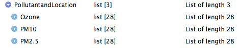

Output of SortByLocation

Now that the data is organized we can calculate the NowCast AQI for Ozone based on location of the sensor using a function called OzoneAQI. The formula for Ozone NowCast concentration is shown in the following photo.

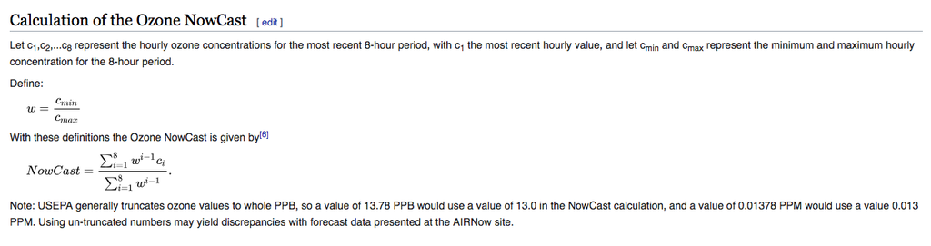

This is the same formula thats given on the EPA website but I thought this was stated more concisely

**OzoneAQI**

```r
OzoneAQI<-function(df) {
  LastEightHours<-head(df,8)
  OzoneConcVar<-LastEightHours[["Ozone.conc"]]
  if(is.na(df[["Ozone.conc"]][1]&df[["Ozone.conc"]][2])==TRUE
     | is.na(df[["Ozone.conc"]][1]&df[["Ozone.conc"]][3])==TRUE
     | is.na(df[["Ozone.conc"]][2]&df[["Ozone.conc"]][3])==TRUE) {
    return("Ozone Nowcast AQI not available")
  } else {
    for(i in 1:8) {
    if(is.na(OzoneConcVar[i]==TRUE))
        OzoneConcVar[i]<-0
    }
    WeightFactor<-1-((max(OzoneConcVar)-min(OzoneConcVar))/max(OzoneConcVar))
    NowCastConc<-floor((OzoneConcVar[1]+(OzoneConcVar[2]*WeightFactor^1)+(OzoneConcVar[3]*WeightFactor^2)+
            (OzoneConcVar[4]*WeightFactor^3)+(OzoneConcVar[5]*WeightFactor^4)+
            +(OzoneConcVar[6]*WeightFactor^5)+(OzoneConcVar[7]*WeightFactor^6)+
            (OzoneConcVar[8]*WeightFactor^7))/(1+WeightFactor^1+WeightFactor^2+WeightFactor^3+WeightFactor^4+WeightFactor^5+WeightFactor^6+WeightFactor^7))
    AQI<-OzoneConcToAQI(NowCastConc)
    return(AQI)
    }
}
```

This function takes the first 8 hours, and begins by checking whether 2 of the three most recent values are valid. If it satisfies the conditions for AQI it calculates the NowCast concentration. Notice at the end of the function theres a local variable defined by:

```r
 AQI<-OzoneConcToAQI(NowCastConc)
```

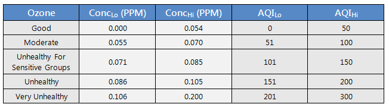

Heres that function

**OzoneConcToAQI**

```r
OzoneConcToAQI<-function(x) {
  if(x>=0&x<=54) {
    ConcLow<-0
    ConcHigh<-54
    AQILow<-0
    AQIHigh<-50
  }
  else if(x>=55&x<=70) {
    ConcLow<-55
    ConcHigh<-70
    AQILow<-51
    AQIHigh<-100
  }
  else if(x>=71&x<=85) {
    ConcLow<-71
    ConcHigh<-86
    AQILow<-101
    AQIHigh<-150
  }
  else if(x>=86&x<=105) {
    ConcLow<-86
    ConcHigh<-105
    AQILow<-151
    AQIHigh<-200

  }
  else if(x>=106&x<=200) {
    ConcLow<-106
    ConcHigh<-200
    AQILow<-201
    AQIHigh<-300
  }
  else {
    print("AQI temperarily unavailable")
  }
  AQI<-round((((AQIHigh-AQILow)/(ConcHigh-ConcLow))*(x-ConcLow))+AQILow)
  return(AQI)
}
```

This is for Ozone being measured in PPB which our dataset doesnt say explicitly but am fairly sure is true.

Since OzoneAQI’s argument can only take in one dataset at a time, I wrote this function that maps OzoneAQI across all datasets for Ozone

**OzoneAQIMap**

```r
OzoneAQIMap<-function(list) {
  lapply(list[["Ozone"]], OzoneAQI)
}
```

Finally, I composed all of these functions into one function that can run through the whole process. The output looks like this:

**OzoneNowCastAQI**

```r
OzoneNowCastAQI<-function(df){
  CleanData<-CleanDataTable(df)
  PollutantLocationNested<-SortByLocation(CleanData)
  FinalResults<-OzoneAQIMap(PollutantLocationNested)
  print(FinalResults)
}

OzoneNowCastAQI(RegData)
```

```
## $`Arvin - Di Giorgio School`
## [1] "Ozone Nowcast AQI not available"
##
## $Atascadero
## [1] 31
##
## $`Bakersfield - California Ave`
## [1] "Ozone Nowcast AQI not available"
##
## $`Bakersfield-Muni`
## [1] "Ozone Nowcast AQI not available"
##
## $`Carrizo Plains School`
## [1] 28
##
## $CDF
## [1] "Ozone Nowcast AQI not available"
##
## $Edison
## [1] "Ozone Nowcast AQI not available"
##
## $`Grover Beach`
## [1] "Ozone Nowcast AQI not available"
##
## $Lebec
## [1] "Ozone Nowcast AQI not available"
##
## $`Lompoc H Street`
## [1] "Ozone Nowcast AQI not available"
##
## $`Lompoc HS&P`
## [1] "Ozone Nowcast AQI not available"
##
## $`Maricopa - Stanilaus Street`
## [1] "Ozone Nowcast AQI not available"
##
## $`Mesa 2`
## [1] "Ozone Nowcast AQI not available"
##
## $`Mobile Monitor`
```

[output cut: 28 more lines]

```
##
## $`Santa Maria`
## [1] "Ozone Nowcast AQI not available"
##
## $`Santa Ynez`
## [1] "Ozone Nowcast AQI not available"
##
## $`Shafter - Walker Street`
## [1] "Ozone Nowcast AQI not available"
##
## $`Temporary PM10`
## [1] "Ozone Nowcast AQI not available"
##
## $`VAFB South Base`
## [1] "Ozone Nowcast AQI not available"
```

The functions for NowCast AQI for PM2.5 and PM10 were constructed pretty similarly. The breaking points to convert NowCast concentration for PM2.5 and PM10 are defined a little differently, which is the main difference in the code. If youd like I can make an R Markdown file going through those too, or I can send you the scripts which have short explanations throughout them.

## Questions/Concerns

1. This process works based on the assumption that the dataset never skips hours. If there are hours in which the value for concentration are NA thats fine, but if row 1 corresponds to 11 am and row 2 corresponds to 9 am the result will be incorrect. Is it fair to assume that wont happen for the regulatory data or should I have my function check for that?
2. I didnt see any literature for how to assign AQI if the Ozone NowCast concentration exceeds 200 PPB. This will output “AQI Temperarily Unavailable” if that happens but I was wondering if there was a way to assign AQI passed that point.